# Finding Impacted Homes by Houston, Texas Blackouts in 2021

Kat Le

2022-10-26

## **Overview**

"In February 2021, the state of Texas suffered a major power crisis, which came about as a result of three severe winter storms sweeping across the United States on February 10–11, 13–17, and 15–20."<sup>1</sup> For more background, check out these [engineering](https://www.youtube.com/watch?v=08mwXICY4JM&ab_channel=PracticalEngineering) and [political](https://www.youtube.com/watch?v=Zcrsgdl_hP0&ab_channel=Vox) perspectives.

For this project, I will be:  
- estimating the number of homes in Houston that lost power as a result of the first two storms  
- investigating if socioeconomic factors are predictors of communities recovery from a power outage

My analysis will be based on remotely-sensed night lights data, acquired from the [Visible Infrared Imaging Radiometer Suite (VIIRS)](https://en.wikipedia.org/wiki/Visible_Infrared_Imaging_Radiometer_Suite) onboard the Suomi satellite. I will use the VNP46A1 to detect differences in night lights before and after the storm to identify areas that lost electric power.

To determine the number of homes that lost power, I link (spatially join) these areas with [OpenStreetMap](https://www.openstreetmap.org/#map=4/38.01/-95.84) data on buildings and roads.

To investigate potential socioeconomic factors that influenced recovery, I will link your analysis with data from the US Census Bureau.

### **Data**

#### **Night lights**

I use NASA's Worldview to explore the data around the day of the storm. There are several days with too much cloud cover to be useful, but 2021-02-07 and 2021-02-16 provide two clear, contrasting images to visualize the extent of the power outage in Texas.

VIIRS data is distributed through NASA's [Level-1 and Atmospheric Archive & Distribution System Distributed Active Archive Center (LAADS DAAC)](https://ladsweb.modaps.eosdis.nasa.gov/). Many NASA Earth data products are distributed in 10x10 degree tiles in sinusoidal equal-area projection. Tiles are identified by their horizontal and vertical position in the grid. Houston lies on the border of tiles h08v05 and h08v06. We therefore need to download two tiles per date.

#### **Roads**

Typically highways account for a large portion of the night lights observable from space (see Google's [Earth at Night](https://earth.google.com/web/@27.44405464,-84.7693044,206.63660162a,8916361.52264659d,35y,0h,0t,0r/data=CiQSIhIgMGY3ZTJkYzdlOGExMTFlNjk5MGQ2ZjgxOGQ2OWE2ZTc)). To minimize falsely identifying areas with reduced traffic as areas without power, we will ignore areas near highways.

[OpenStreetMap (OSM)](https://planet.openstreetmap.org/) is a collaborative project which creates publicly available geographic data of the world. Ingesting this data into a database where it can be subsetted and processed is a large undertaking. Fortunately, third party companies redistribute OSM data. We used [Geofabrik's download sites](https://download.geofabrik.de/) to retrieve a shapefile of all highways in Texas and prepared a Geopackage (`.gpkg` file) containing just the subset of roads that intersect the Houston metropolitan area.

#### **Houses**

We can also obtain building data from OpenStreetMap. We again downloaded from Geofabrick and prepared a GeoPackage containing only houses in the Houston metropolitan area.

- `gis_osm_buildings_a_free_1.gpkg`

#### **Socioeconomic**

We cannot readily get socioeconomic information for every home, so instead we obtained data from the [U.S. Census Bureau's American Community Survey](https://www.census.gov/programs-surveys/acs) for census tracts in 2019.

```r
library(tidyverse)
library(sf)
library(stars)
library(here)
library(cubelyr)
library(tmap)
library(ggspatial)
library(ggsn)
library(plotly)
library(gt)
library(patchwork)
```

```r
# read in tile data
light_data1 <- read_stars(here("data/VNP46A1/VNP46A1.A2021038.h08v05.001.2021039064328.tif"))
light_data2 <- read_stars(here("data/VNP46A1/VNP46A1.A2021038.h08v06.001.2021039064329.tif"))
light_data3 <- read_stars(here("data/VNP46A1/VNP46A1.A2021047.h08v05.001.2021048091106.tif"))
light_data4 <- read_stars(here("data/VNP46A1/VNP46A1.A2021047.h08v06.001.2021048091105.tif"))

# combine tiles
light_0207 <- st_mosaic(light_data1, light_data2)
light_0216 <- st_mosaic(light_data3, light_data4)

# change attribute names to something that makes more sense
light_0207 <- setNames(light_0207, "light_intensity")
light_0216 <- setNames(light_0216, "light_intensity")
```

## create a blackout mask

- find the change in night lights intensity (presumably) caused by the storm
- reclassify the difference raster, assuming that any location that experienced a drop of more than 200 nW cm<sup>-2</sup>sr<sup>-1</sup> experienced a blackout
- assign `NA` to all locations that experienced a drop of *less* than 200 nW cm<sup>-2</sup>sr<sup>-1</sup>

```r
# TEST: check dimensions
if(length(light_0207[[1]]) == length(light_0216[[1]])) {
  print("Dimensions match!")
} else {
  print("Dimensions don't match")
}
```

```
## [1] "Dimensions match!"
```

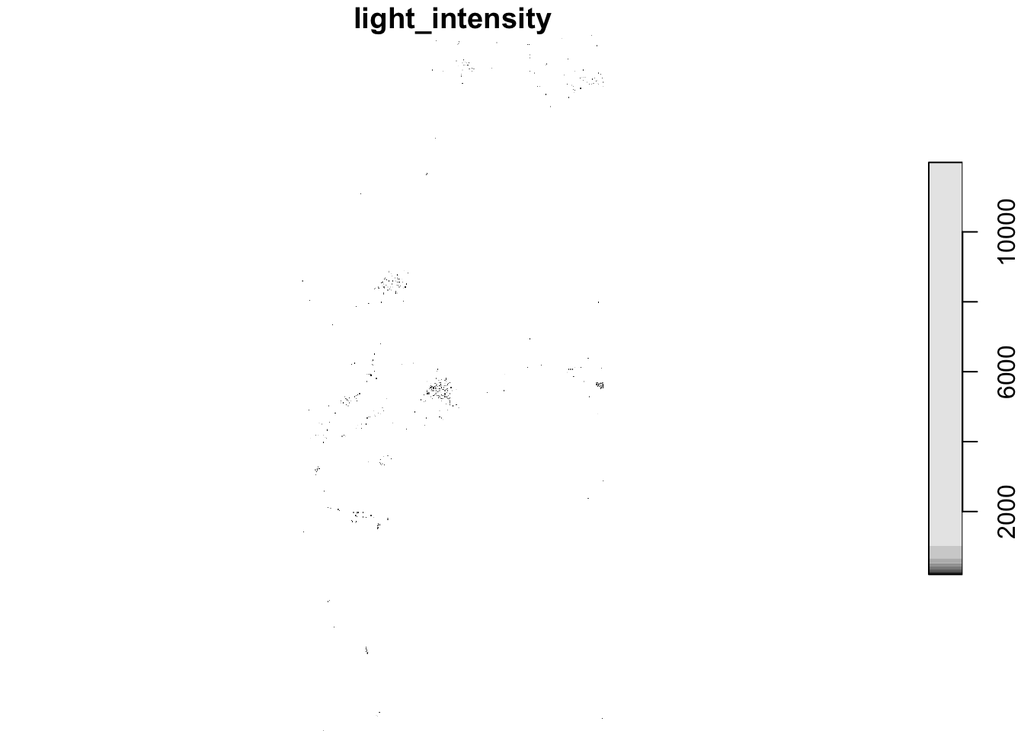

```r
# find difference between 02/07 (baseline) and 02/16 (during storm)
blackout_mask <- light_0207 - light_0216

# assign NAs to light values of less than 200
blackout_mask[blackout_mask <= 200] = NA

# TEST: plot to see blackout data
plot(blackout_mask)
```

## vectorize the mask

- use `st_as_sf()` to vectorize the blackout mask
- fix any invalid geometries using `st_make_valid`

```r
# turn mask in vector and fix any invalid geometries
vec_blackout_mask <-st_as_sf(blackout_mask) %>%
  st_make_valid()
```

## crop the vectorized map to our region of interest

- define the Houston metropolitan area with the following coordinates
  - (-96.5, 29), (-96.5, 30.5), (-94.5, 30.5), (-94.5, 29)
- turn these coordinates into a polygon using `st_polygon`
- convert the polygon into a simple feature collection using `st_sfc()` and assign a CRS
- crop (spatially subset) the blackout mask to our region of interest
- re-project the cropped blackout dataset to EPSG:3083 (NAD83 / Texas Centric Albers Equal Area)

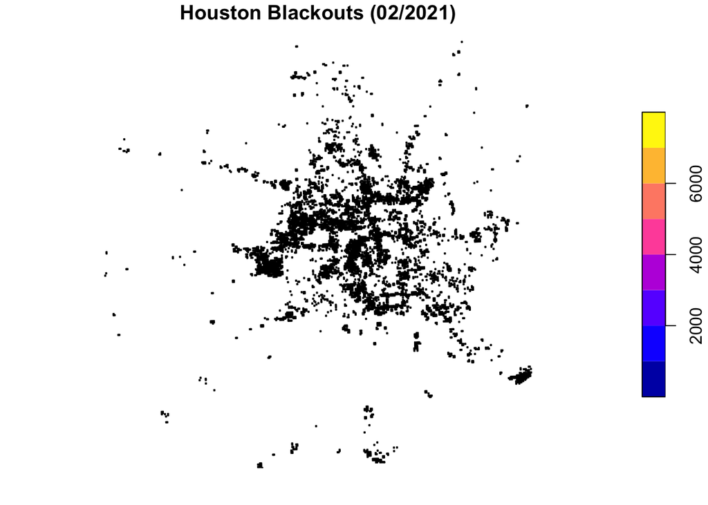

```r
# create matrix for houston bbox
houston <- matrix(c(-96.5, 29,
                    -96.5, 30.5,
                    -94.5, 30.5,
                    -94.5, 29,
                    -96.5, 29),
                  ncol = 2, byrow = TRUE)

# turn houston matrix into a polygon, turn polygon into an sf object, and assign CRS to match blackout mask
houston <- st_sfc(st_polygon(list(houston)), crs = st_crs(vec_blackout_mask))

# crop vectorized blackout mask to only show houston
houston_mask <- st_crop(vec_blackout_mask, houston)

# reproject to texa's equal area projection
houston_mask_3083 <- st_transform(houston_mask, crs = 3083)

# TEST: plot to see if blackout data is cropped to houston area
plot(houston_mask_3083, main = "Houston Blackouts (02/2021)")
```

### exclude highways from blackout mask

- define SQL query
- load just highway data from geopackage using `st_read`
- reproject data to EPSG:3083
- identify areas within 200m of all highways using `st_buffer`
  - hint: `st_buffer` produces undissolved buffers, use `st_union` to dissolve them
- find areas that experienced blackouts that are further than 200m from a highway

```r
# sql query + read in highway data
query <- "SELECT * FROM gis_osm_roads_free_1 WHERE fclass='motorway'"
highways <- st_read("data/gis_osm_roads_free_1.gpkg", query = query)
```

```
## Reading query `SELECT * FROM gis_osm_roads_free_1 WHERE fclass='motorway''
## from data source `/Users/katle/Desktop/Desktop - kat’s MacBook Air/github/finding-impacted-homes-of-houston-blackouts-2021/data/gis_osm_roads_free_1.gpkg'
##   using driver `GPKG'
## Simple feature collection with 6085 features and 10 fields
## Geometry type: LINESTRING
## Dimension:     XY
## Bounding box:  xmin: -96.50429 ymin: 29.00174 xmax: -94.39619 ymax: 30.50886
## Geodetic CRS:  WGS 84
```

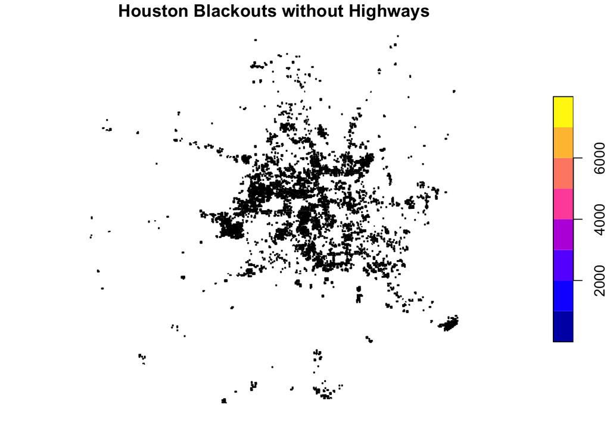

```r
# set CRS for highways object
highways <- st_transform(highways, crs = 3083)

# join highways to houston mask
highways_houston <- highways[houston_mask_3083,]

# create buffer
highway_buffer_undissolved <- st_buffer(highways_houston, dist = 200)

# dissolve buffer into one geometry
highway_buffer <- st_union(highway_buffer_undissolved)

# find where highway_buffer and houston_mask_3083 are not overlapping
houston_blackout_without_hwy <- st_difference(houston_mask_3083, highway_buffer)

# TEST: plot to check
plot(houston_blackout_without_hwy, main = "Houston Blackouts without Highways")
```

## Find homes impacted by blackouts

### load buildings data

- load buildings dataset using `st_read` and the following SQL query to select only residential buildings

`SELECT *` `FROM gis_osm_buildings_a_free_1`  
`WHERE (type IS NULL AND name IS NULL)`  
`OR type in ('residential', 'apartments', 'house', 'static_caravan', 'detached')`

```r
# define new sql query for residential buildings
query2 <- "SELECT * FROM gis_osm_buildings_a_free_1 WHERE (type IS NULL AND name IS NULL) OR type in ('residential', 'apartments', 'house', 'static_caravan', 'detached')"

# read in building data + pass sql query from above
buildings <- st_read("data/gis_osm_buildings_a_free_1.gpkg", query = query2)
```

```
## Reading query `SELECT * FROM gis_osm_buildings_a_free_1 WHERE (type IS NULL AND name IS NULL) OR type in ('residential', 'apartments', 'house', 'static_caravan', 'detached')'
## from data source `/Users/katle/Desktop/Desktop - kat’s MacBook Air/github/finding-impacted-homes-of-houston-blackouts-2021/data/gis_osm_buildings_a_free_1.gpkg'
##   using driver `GPKG'
## Simple feature collection with 475941 features and 5 fields
## Geometry type: MULTIPOLYGON
## Dimension:     XY
## Bounding box:  xmin: -96.50055 ymin: 29.00344 xmax: -94.53285 ymax: 30.50393
## Geodetic CRS:  WGS 84
```

```r
# reproject into texas' equal area projection
buildings <- st_transform(buildings, crs = 3083)
```

### find homes in blackout areas

- filter to homes within blackout areas
- count number of impacted homes

```r
# filter to find out how many buildings are in blackout areas of houston without highway lights
blackout_buildings <- st_filter(buildings, houston_blackout_without_hwy)

paste0("The number of homes within blackout areas of Houston is ", n_distinct(blackout_buildings$osm_id), ".")
```

```
## [1] "The number of homes within blackout areas of Houston is 157518."
```

## Investigate socioeconomic factors

### load ACS data

- use `st_read()` to load the geodatabase layers
- geometries are stored in the `ACS_2019_5YR_TRACT_48_TEXAS` layer
- income data is stored in the `X19_INCOME` layer
- select the median income field `B19013e1`

```r
# read in census layer and transform to 3083
census_tract <- st_read(here("data/ACS_2019_5YR_TRACT_48_TEXAS.gdb/"), layer = "ACS_2019_5YR_TRACT_48_TEXAS") %>%
  st_transform(crs = 3083)

# read in income layer from .gdb
income <- st_read(here("data/ACS_2019_5YR_TRACT_48_TEXAS.gdb/"), layer = "X19_INCOME") %>%
 select("GEOID", "B19013e1")
```

### determine which census tracts experienced blackouts

- join the income data to the census tract geometries
- spatially join census tract data with buildings determined to be impacted by blackouts
- find which census tracts had blackouts

```r
# join income data to census tract
census_income <- left_join(census_tract, income, by = c("GEOID_Data" = "GEOID")) %>%
   mutate("median_income" = B19013e1)

# TEST: Print TRUE if length of joined census + income data matches number of census tracts
if(nrow(census_income) == length(unique(census_tract$GEOID_Data))){
  print("TRUE, rows of joined census+income data matches number of census tracts")
} else{
  print("CHECK YOUR JOIN: Number of rows of joined census + income data does not match number of census tracts")
}
```

```
## [1] "TRUE, rows of joined census+income data matches number of census tracts"
```

```r
# crop census+income data to only include houston metropolitan area
census_income_houston_crop <- st_crop(census_income,
                                      st_as_sf(st_transform(houston, crs = 3083)))

# spatially join houston census+income data to buildings impacted by blackout then
houston_census_blackout_join <- st_join(blackout_buildings, census_income_houston_crop)
```

```r
# find which census tracts had blackouts

# for census tracts with blackouts, filter census_income_houston_crop for rows that intersect with the joined census+income+blackout data:
census_tract_blackout_true <- st_filter(census_income_houston_crop,
                                        blackout_buildings)
```

```r
# find census tracts that weren't impacted by blackouts:
# filter for census tracts not impacted by blackouts
census_tract_blackout_false <- census_income_houston_crop %>%
   filter(!GEOID %in% unique(houston_census_blackout_join$GEOID))
```

### compare incomes of impacted tracts to unimpacted tracts

- create a map of median income by census tract, designating which tracts had blackouts
- plot the distribution of income in impacted and unimpacted tracts

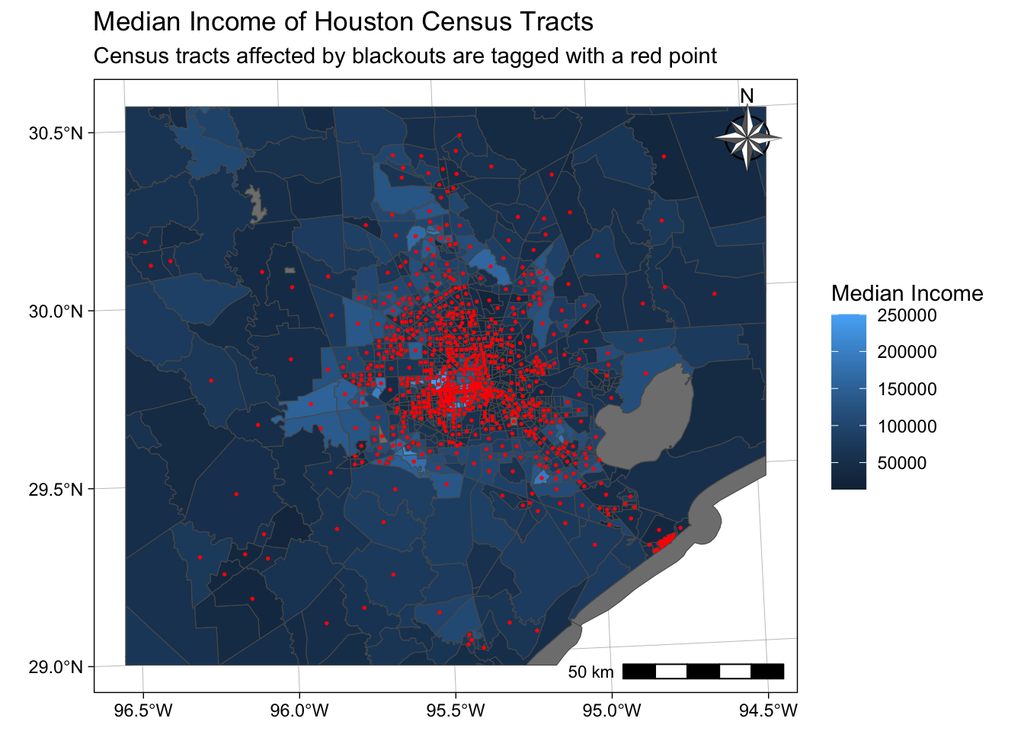

```r
# create map of census income data and indicate impact of blackouts with centroids
median_income <- ggplot() +
  geom_sf(data = census_income_houston_crop, aes(fill = median_income)) +
  geom_sf(data = st_centroid(census_tract_blackout_true),
          size = 0.3, color = "red") +
  annotation_scale(data = census_income_houston_crop, location = "br") +
  theme_linedraw() +
  labs(title = "Median Income of Houston Census Tracts",
       subtitle = "Census tracts affected by blackouts are tagged with a red point",
       fill = "Median Income") +
    annotation_north_arrow(location = "tr",
                           pad_x = unit(0.05, "in"),
                           pad_y = unit(0.05, "in"),
                           style = ggspatial::north_arrow_nautical(fill = c("grey40", "white")))

median_income
```

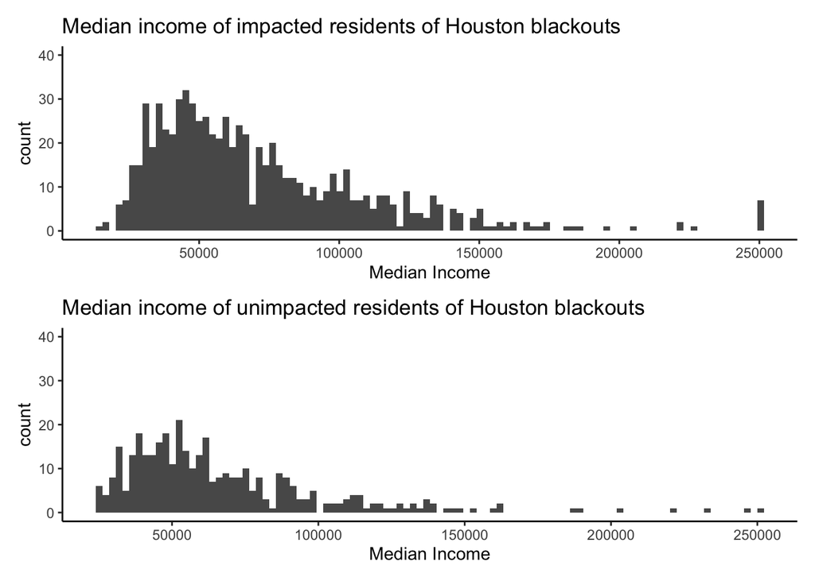

```r
# create histogram of median income of census tracts impacted by blackouts
impacted_hist <- ggplot(data = census_tract_blackout_true,
                        aes(x = median_income)) +
  geom_histogram(bins = 100) +
  ylim(0, 40) +
  labs(title = 'Median income of impacted residents of Houston blackouts',
       x = 'Median Income',
       y = 'count') +
  theme_classic()

# create histogram of median income of census tracts that were unimpacted by blackouts
unimpacted_hist <- ggplot(data = census_tract_blackout_false,
                          aes(x = median_income)) +
  geom_histogram(bins = 100) +
  ylim(0, 40) +
  labs(title = 'Median income of unimpacted residents of Houston blackouts',
       x = 'Median Income',
       y = 'count') +
  theme_classic()

impacted_hist / unimpacted_hist
```

## Conclusion:

To analyze the effects of the Houston storms in February of 2021, satellite images of light intensity were analyzed to see how many residential buildings lost power. This analysis estimates that around 157518 buildings lost power. When comparing the distribution of median incomes by affected versus unaffected residents using census tract data, the distributions seem to be relatively similar. This could mean that the storm was so widespread, it caused blackouts throughout much of Houston, regardless of socioeconomic status.

There are several limitations to consider in this analysis. First, this study was only able to analyze buildings that were 200 meters away from a highway because the light produced by cars would interfere with the analysis. This would likely exclude many residential buildings that house residents with lower income. In addition, this analysis only took into account whether or not a blackout occurred in a census track. In future studies, it is also important to consider the proportion of homes within each census track that lost power in order to understand the relationship between storms and socioeconomic status.